# Ejercicio Regresión

# Instrucciones

## Objetivo

1. El ejercicio consiste en realizar un análisis de regresión para la serie que eligieron, con el propósito de **realizar pronósticos a 3 años**.
2. Lo primero que deben realizar es un análisis exploratorio de su variable de pronóstico *(saber qué es, para qué se utiliza, cómo se mide, en qué unidades está, etc.)*.
3. Posteriormente, deben elegir **al menos 8 series predictoras** que consideren que pueden ayudar a pronosticar la variable objetivo. *(recuerden que las series predictoras deben tener sentido económico y estar relacionadas con la variable a pronosticar)*. Para esto, pueden apoyarse de la inteligencia artificial para que les sugiera posibles series predictoras:
- Les sugiero utilizar el GPT diseñado especialmente para la materia, [**Elendil TA**](https://chatgpt.com/g/g-68e6907c12a48191a07fb0888500a7fa-elendil-ta).
- Ustedes deben cuestionar y validar las sugerencias que les haga la IA. Aquí el papel del analista es fundamental. *(es lo que va a impedir que se queden sin chamba o que sean reemplazados por una IA en el futuro, o que queden como* 🤡*)*.
- Idealmente, las series que van a elegir deben ser series económicas que se puedan descargar desde FRED *(para facilitar su descarga)*.
4. Ya que tengan las predictoras, realizar el análisis de regresión completo y evaluar si todas esas predictoras se van a quedar en el modelo final o si se debe quitar alguna.
- Recuerden evaluar los supuestos del modelo de regresión lineal múltiple.
- Pueden utilizar técnicas de selección de variables si lo consideran necesario.
- Justifiquen todas sus decisiones y muestren el procedimiento que siguieron.
5. Finalmente, realicen los tres tipos de pronósticos que vimos para regresión a 3 años y evalúen su desempeño utilizando las métricas que consideren adecuadas. Para los pronósticos basados en escenarios, definir arbitrariamente 2 escenarios:
- **Optimista:** El desempeño de su variable de pronóstico mejora (dependiendo la variable que les tocó, esto podria significar que aumente o disminuya).
- **Pesimista:** El desempeño de su variable de pronóstico empeora.

**Sobre los tipos de pronóstico**

La diferencia entre los tipos de pronóstico es qué se hace con las predictoras (las $x$):

### Ex-post

Es cuando separamos en train/test y se usan los valores reales del test en las $x$ (*No son pronósticos reales*).

### Ex-ante

**Se deben pronosticar las predictoras** primero y luego usar esos pronósticos para hacer el pronóstico. (*estos son los únicos pronósticos reales*).

### Escenarios

Se definen cuantos escenarios quieran y se eligen arbitrariamente los valores de las $x$, dependiendo lo que se quiera evaluar (*es como si se plantearan ¿qué pasaría si…?*).

## Formato de entrega

1. Todo el ejercicio debe estar contenido en un documento de **Quarto** `(.qmd)` con formato de salida `revealjs` (presentación de html) o `pptx`(PowerPoint).

En las presentaciones, el código se oculta por default, si quieren que algún chunk muestre el código, es necesario agregar la opción `echo: true` al chunk. P. ej.:

```
#| echo: true

1 + 1
```

**Encabezado YAML para los formatos de salida**

### `revealjs`

```
---
format:
  revealjs:
    scrollable: true
    incremental: true
    theme: default
    embed-resources: true
---
```

- Pueden consultar la documentación aquí: [Revealjs Quarto](https://quarto.org/docs/presentations/revealjs/)

### `pptx`

```
---
format:
  pptx:
    incremental: true
---
```

- Pueden consultar la documentación aquí: [PowerPoint Quarto](https://quarto.org/docs/presentations/powerpoint.html)

# Datos y código de muestra

## Descarga de datos

```r
series <- c("RSXFSN", "UNRATENSA", "PPIACO", "IPN221114T8N", "PERMITNSA")

data_raw <- tidyquant::tq_get(
  x    = series,
  get  = "economic.data",
  from = "1960-01-01"
)

data_raw
```

**1**

El listado de series que queremos descargar

**2**

Fecha de inicio de las series

```
# A tibble: 3,062 × 3
   symbol date        price
   <chr>  <date>      <dbl>
 1 RSXFSN 1992-01-01 126717
 2 RSXFSN 1992-02-01 127022
 3 RSXFSN 1992-03-01 137978
 4 RSXFSN 1992-04-01 142314
 5 RSXFSN 1992-05-01 147550
 6 RSXFSN 1992-06-01 146991
 7 RSXFSN 1992-07-01 147657
 8 RSXFSN 1992-08-01 147901
 9 RSXFSN 1992-09-01 143808
10 RSXFSN 1992-10-01 151260
# ℹ 3,052 more rows
```

**Important**

Las series a modelar tienen una periodicidad **mensual**, por lo que es importante asegurarse de que las predictoras que hayan elegido para el análisis también tengan la misma periodicidad.

## Transformación a tsibble

### `tsibble` en formato largo

```r
data_tsb_long <- data_raw |>
  mutate(date = yearmonth(date)) |>
  as_tsibble(key = symbol, index = date)

data_tsb_long
```

**1**

La `tsibble` así como la descargamos está en formato **largo *(long)*** . Este formato nos va a ser útil para realizar análisis o modelar todas las predictoras **simultánemente**, pero no para hacer la regresión.

```
# A tsibble: 3,062 x 3 [1M]
# Key:       symbol [5]
   symbol            date price
   <chr>            <mth> <dbl>
 1 IPN221114T8N 2001 ene.  13.0
 2 IPN221114T8N 2001 feb.  13.0
 3 IPN221114T8N 2001 mar.  13.2
 4 IPN221114T8N 2001 abr.  13.5
 5 IPN221114T8N 2001 may.  13.3
 6 IPN221114T8N 2001 jun.  14.3
 7 IPN221114T8N 2001 jul.  14.2
 8 IPN221114T8N 2001 ago.  14.0
 9 IPN221114T8N 2001 sep.  13.4
10 IPN221114T8N 2001 oct.  13.1
# ℹ 3,052 more rows
```

### `tsibble` en formato ancho

```r
data_tsb_wide <- data_tsb_long |>
  pivot_wider(names_from = symbol, values_from = price) |>
  relocate(date, RSXFSN)

data_tsb_wide
```

**2**

Convertimos la `tsibble` a formato **ancho *(wide)*** , que es el formato que necesitamos para hacer la regresión.

**3**

Reordenamos las columnas para que la variable de pronóstico esté al principio. Sustituyan `RSXFSN` por la variable que les tocó pronosticar.

```
# A tsibble: 788 x 6 [1M]
        date RSXFSN IPN221114T8N PERMITNSA PPIACO UNRATENSA
       <mth>  <dbl>        <dbl>     <dbl>  <dbl>     <dbl>
 1 2001 ene. 221577         13.0      117    140        4.7
 2 2001 feb. 218731         13.0      114.   137.       4.6
 3 2001 mar. 247585         13.2      148.   136.       4.5
 4 2001 abr. 243520         13.5      149.   136.       4.2
 5 2001 may. 262673         13.3      160.   137.       4.1
 6 2001 jun. 254671         14.3      154.   136.       4.7
 7 2001 jul. 246061         14.2      141.   133.       4.7
 8 2001 ago. 260695         14.0      151.   133.       4.9
 9 2001 sep. 231126         13.4      125.   133.       4.7
10 2001 oct. 259459         13.1      140.   130.       5
# ℹ 778 more rows
```

**Ejemplo de visualización de todas las series**

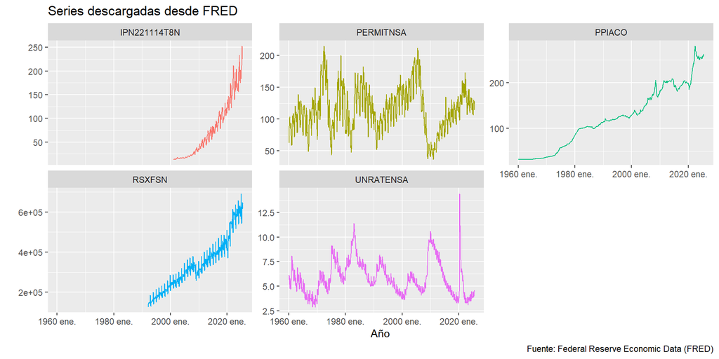

```r
data_tsb_long |>
  autoplot(price) +
  facet_wrap(vars(symbol), scales = "free_y") +
  theme(legend.position = "none") +
  labs(
    title   = "Series descargadas desde FRED",
    x       = "Año",
    y       = "",
    caption = "Fuente: Federal Reserve Economic Data (FRED)"
  )
```